# Eastern Shore Broadband Availability

Lee LeBoeuf

7/29/2021

## Data Source

- These data come from the FCC's data on broadband availability.
- FCC data is released biannually on a year and half delay from when it was collected. New data can be downloaded from this [link](https://www.fcc.gov/general/broadband-deployment-data-fcc-form-477).
- Data presented here are from June of 2020.

## Data specifics

- All internet providers must submit form 477 to the FCC biannually detailing the Maximum download and upload speeds (Mbps) they advertise to consumers along with other information about the company.
- The FCC makes these data publicly available on a year and a half delay from when all 477 forms are submitted.
  - Limitations: (1) The data are available at the census block level, but are likely to overstate coverage because if an internet provider provides internet to a single person in a census block, the entire census block is marked as having coverage by that provider.
  - Strengths: (1) These are the same data used by the government to make policy decisions regarding broadband access. (2) Trump signed an [act into law](https://www.commerce.senate.gov/2020/3/bill-to-improve-broadband-data-maps-signed-into-law) in March of 2020 that is supposed to improve the limitation listed above.

## Variable descriptions

```r
meta %>%
  filter(su_tract == 1) %>%
  select(varname, about) %>% as.list()
```

```
## $varname
## [1] "tract"           "consproviders"   "busproviders"    "avgMaxAdDown"
## [5] "avgMaxAdUp"      "p_under25.3mbps"
##
## $about
## [1] "11-digit tract code"
## [2] "The number of consumer internet providers in the su"
## [3] "The number of business internet providers in the su"
## [4] "The average maximum advertised download speed by each broadband provider in the su"
## [5] "The average maxmum advertised upload speed by each broadband provider in the su"
## [6] "The proportion of census blocks within the block group/tract that have internet speeds under 25/3 Mbps, and therefore don't meet the FCC benchmark for \"advanced telecommunications capability\""
```

```r
glimpse(eastdat)
```

```
## Rows: 16
## Columns: 6
## $ tract           <dbl> 51001090100, 51001090200, 51001090300, 51001090400, 51…
## $ consproviders   <int> 9, 9, 8, 7, 8, 9, 8, 7, 6, 8, 1, 2, 8, 9, 9, 4
## $ busproviders    <int> 13, 13, 11, 11, 10, 11, 11, 11, 7, 10, 1, 2, 12, 11, 1…
## $ avgMaxAdDown    <dbl> 295.68376, 239.30274, 260.61315, 237.21925, 310.15546,…
## $ avgMaxAdUp      <dbl> 156.29902, 153.25942, 165.66325, 133.91491, 190.56473,…
## $ p_under25.3mbps <dbl> 0.03216374, 0.29842932, 0.25352113, 0.19427711, 0.0643…
```

```r
eastdat %>% select(consproviders, busproviders, avgMaxAdDown, avgMaxAdUp, p_under25.3mbps) %>%
  select(where(~is.numeric(.x))) %>%
  as.data.frame() %>%
  stargazer(., type = "text", title = "Summary Statistics", digits = 2,
            summary.stat = c("mean", "sd", "min", "median", "max"))
```

```
##
## Summary Statistics
## ===================================================
## Statistic        Mean  St. Dev.  Min  Median  Max
## ---------------------------------------------------
## consproviders    7.00    2.53     1     8      9
## busproviders     9.31    3.75     1     11     13
## avgMaxAdDown    231.80  96.43   57.94 247.70 439.10
## avgMaxAdUp      143.88  82.85   3.00  156.25 362.74
## p_under25.3mbps  0.10    0.15   0.00   0.00   0.44
## ---------------------------------------------------
```

## Visual distribution

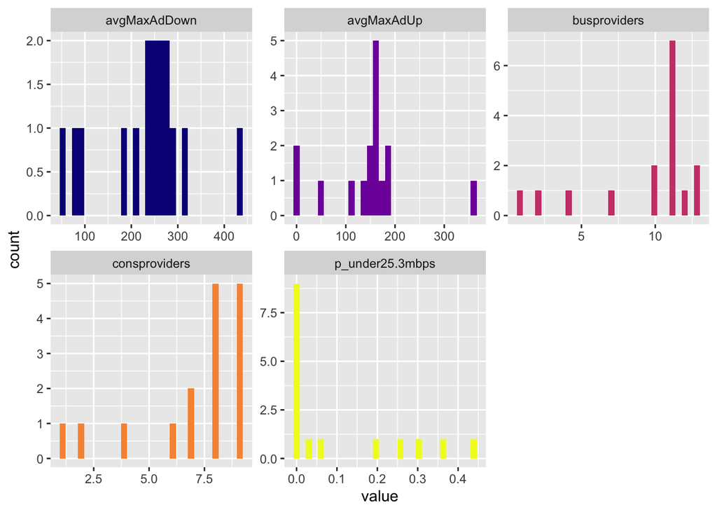

```r
eastdat %>% select(c(tract, consproviders, busproviders, avgMaxAdDown, avgMaxAdUp, p_under25.3mbps)) %>%
  pivot_longer(-tract, names_to = "measure", values_to = "value") %>%
  ggplot(aes(x = value, fill = measure)) +
  scale_fill_viridis(option = "plasma", discrete = TRUE, guide = FALSE) +
  geom_histogram() +
  facet_wrap(~measure, scales = "free")
```

```r
meta %>%
  filter(varname %in% c("consproviders", "busproviders", "avgMaxAdDown", "avgMaxAdUp", "p_under25.3mbps")) %>%
  mutate(label = paste0(varname, ": ", about)) %>%
  select(label) %>%
  as.list()
```

$label [1] "consproviders: The number of consumer internet providers in the su"  
[2] "busproviders: The number of business internet providers in the su"  
[3] "avgMaxAdDown: The average maximum advertised download speed by each broadband provider in the su"  
[4] "avgMaxAdUp: The average maxmum advertised upload speed by each broadband provider in the su"  
[5] "p_under25.3mbps: The proportion of census blocks within the block group/tract that have internet speeds under 25/3 Mbps, and therefore don't meet the FCC benchmark for "advanced telecommunications capability""

## Mapping the data

### Number of consumer internet providers

```r
pal <- colorNumeric("plasma", reverse = TRUE, domain = mapdat$consproviders)

leaflet() %>%
  addProviderTiles("CartoDB.Positron") %>%
  addPolygons(data = mapdat,
              fillColor = ~pal(consproviders),
              weight = 1,
              opacity = 1,
              color = "white",
              fillOpacity = 0.6,
              highlight = highlightOptions(
                weight = 2,
                fillOpacity = 0.8,
                bringToFront = T
              ),
              popup = paste0("GEOID: ", mapdat$tract, "<br>",
                             "Number of internet providers: ", mapdat$consproviders)
  ) %>%
  addLegend("bottomright", pal = pal, values = mapdat$consproviders,
            title = "Number of internet <br> providers per tract", opacity = 0.7)
```

[interactive chart not shown]

### Average maximum advertised download speeds

```r
pal <- colorNumeric("plasma", reverse = TRUE, domain = mapdat$avgMaxAdDown)

leaflet() %>%
  addProviderTiles("CartoDB.Positron") %>%
  addPolygons(data = mapdat,
              fillColor = ~pal(avgMaxAdDown),
              weight = 1,
              opacity = 1,
              color = "white",
              fillOpacity = 0.6,
              highlight = highlightOptions(
                weight = 2,
                fillOpacity = 0.8,
                bringToFront = T
              ),
              popup = paste0("GEOID: ", mapdat$tract, "<br>",
                             "Average max advertised <br> download speeds: ", round(mapdat$avgMaxAdDown, 2))
  ) %>%
  addLegend("bottomright", pal = pal, values = mapdat$avgMaxAdDown,
            title = "Average maximum <br> advertised download <br> speeds per tract", opacity = 0.7)
```

[interactive chart not shown]

### Average maximum advertised upload speeds

```r
pal <- colorNumeric("plasma", reverse = TRUE, domain = mapdat$avgMaxAdUp)

leaflet() %>%
  addProviderTiles("CartoDB.Positron") %>%
  addPolygons(data = mapdat,
              fillColor = ~pal(avgMaxAdUp),
              weight = 1,
              opacity = 1,
              color = "white",
              fillOpacity = 0.6,
              highlight = highlightOptions(
                weight = 2,
                fillOpacity = 0.8,
                bringToFront = T
              ),
              popup = paste0("GEOID: ", mapdat$tract, "<br>",
                             "Average max <br> advertised upload speeds: ", round(mapdat$avgMaxAdUp, 2))
  ) %>%
  addLegend("bottomright", pal = pal, values = mapdat$avgMaxAdUp,
            title = "Average maximum <br> advertised <br> upload speeds per tract", opacity = 0.7)
```

[interactive chart not shown]

### Percent of blocks that don't meet the FCC threshold for "advanced telecommunications capability"

- Percent of blocks in the spatial unit that do not meet the 25/3 Mbps bandwidth based on their providers' average maximum advertised download and upload speeds

```r
pal <- colorNumeric("plasma", reverse = TRUE, domain = (mapdat$p_under25.3mbps *100))

leaflet() %>%
  addProviderTiles("CartoDB.Positron") %>%
  addPolygons(data = mapdat,
              fillColor = ~pal((mapdat$p_under25.3mbps *100)),
              weight = 1,
              opacity = 1,
              color = "white",
              fillOpacity = 0.6,
              highlight = highlightOptions(
                weight = 2,
                fillOpacity = 0.8,
                bringToFront = T
              ),
              popup = paste0("GEOID: ", mapdat$tract, "<br>",
                             "Percent of blocks  <br>without advanced  <br>telecommunications capability: ", round((mapdat$p_under25.3mbps *100), 2))
  ) %>%
  addLegend("bottomright", pal = pal, values = (mapdat$p_under25.3mbps *100),
            title = "Percent of blocks  <br>without advanced  <br>telecommunications capability", opacity = 0.7)
```

[interactive chart not shown]